# Analise_conteudo

[figure not shown]

**Mestrado em Ciência de Dados para Ciências Sociais**

**Universidade de Aveiro**

Introdução à Ciência de Dados - 2024/2025

Magda Matias | N.º Mec.: 50091  
Rita Gonçalves | N.º Mec.: 30099

# Pré-processamento dos dados exportados da Scopus

## Configurações

```python
# Importar bibliotecas
import numpy as np
import pandas as pd
import nltk
from nltk.corpus import stopwords
from nltk.tokenize import word_tokenize
from nltk.stem import PorterStemmer

import matplotlib.pyplot as plt

from gensim.corpora import Dictionary
from gensim.models import LdaModel


# Descarregar stopwords
nltk.download('stopwords')
nltk.download('punkt')

import pyLDAvis
import pyLDAvis.gensim_models as gensimvis
```

## Instalação de bibliotecas

```python
# Instalar bibliotecas

#!pip install pandas
#!pip install numpy
#!pip install nltk
#!pip install spacy
#!pip install scikit-learn
# pip install contractions
#pip install pyLDAvis


# Importar bibliotecas
import pandas as pd
import numpy as np
import nltk
import spacy
import sklearn

import re
import contractions
nltk.download('punkt')
nltk.download('all')
from nltk.corpus import stopwords
from nltk import word_tokenize

# Para a lematização/stemming
from nltk.stem import WordNetLemmatizer
from nltk.stem import PorterStemmer

from nltk import pos_tag

from sklearn.feature_extraction.text import CountVectorizer
from sklearn.feature_extraction.text import TfidfVectorizer

# Visualização
import matplotlib.pyplot as plt
import seaborn as sns

# Nuvem de palavras para verificar as palavras mais frequentes e acrescentar palavras adicionais à lista de stopwords
from wordcloud import WordCloud, STOPWORDS, ImageColorGenerator

# Modelação
from gensim.corpora import Dictionary
from gensim.models import LdaModel

# Visualização interativa do modelo de tópicos
import pyLDAvis
import pyLDAvis.gensim_models as gensimvis

# Clusters
from sklearn.cluster import KMeans

import warnings
warnings.filterwarnings("ignore")
```

## Carregamento dos dados

```python
# Carregar o ficheiro CSV num DataFrame
df = pd.read_csv(r'scopus.csv')
```

## Características do conjunto de dados

```python
# Verificar a forma do conjunto de dados
df.shape
```

```
(243, 34)
```

```python
# Ver as primeiras 3 linhas do conjunto de dados
df.head(3)
```

|  | Authors | Author full names | Author(s) ID | Title | Year | Source title | Volume | Issue | Art. No. | Page start | ... | ISBN | CODEN | PubMed ID | Language of Original Document | Abbreviated Source Title | Document Type | Publication Stage | Open Access | Source | EID |
| --- | --- | --- | --- | --- | --- | --- | --- | --- | --- | --- | --- | --- | --- | --- | --- | --- | --- | --- | --- | --- | --- |
| 0 | Grüger H.; Knobbe J.; Pügner T. | Grüger, Heinrich (6602682760); Knobbe, Jens (6... | 6602682760; 6506736925; 34168234400 | Multi- and hyperspectral imaging of plants and... | 2024 | Proceedings of SPIE - The International Societ... | 12879 | NaN | 1287903 | NaN | ... | 978-151067018-1 | PSISD | NaN | English | Proc SPIE Int Soc Opt Eng | Conference paper | Final | NaN | Scopus | 2-s2.0-85190967516 |
| 1 | Pazo M.; Gerassis S.; Araújo M.; Margarida Ant... | Pazo, M. (57240871600); Gerassis, S. (57193055... | 57240871600; 57193055708; 36560944600; 5898070... | Enhancing water quality prediction for fluctua... | 2024 | Science of the Total Environment | 927 | NaN | 172340 | NaN | ... | NaN | STEVA | 38608909.0 | English | Sci. Total Environ. | Article | Final | All Open Access; Hybrid Gold Open Access | Scopus | 2-s2.0-85190066682 |
| 2 | Kim Y.J.; Liu Y.; Kim Y.; Jang H.W. | Kim, Yeong Jae (58797203500); Liu, Yang (57105... | 58797203500; 57105982500; 56447473500; 7202135252 | Publications on COVID-19 and artificial intell... | 2024 | Science Editing | 11 | 2 | NaN | 142 | ... | NaN | NaN | NaN | English | Sci. Ed. | Article | Final | All Open Access; Gold Open Access | Scopus | 2-s2.0-85201915184 |

3 rows × 34 columns

```python
# Ver as últimas 3 linhas do conjunto de dados
df.tail(3)
```

|  | Authors | Author full names | Author(s) ID | Title | Year | Source title | Volume | Issue | Art. No. | Page start | ... | ISBN | CODEN | PubMed ID | Language of Original Document | Abbreviated Source Title | Document Type | Publication Stage | Open Access | Source | EID |
| --- | --- | --- | --- | --- | --- | --- | --- | --- | --- | --- | --- | --- | --- | --- | --- | --- | --- | --- | --- | --- | --- |
| 240 | Lipinski T.A.; Henderson K.A. | Lipinski, Tomas A. (6603663810); Henderson, Ka... | 6603663810; 57207824745 | Fake Science: Legal implications in the creati... | 2020 | GL-Conference Series: Conference Proceedings | 2020-November | NaN | NaN | 105 | ... | 978-907748438-8 | NaN | NaN | English | GL-Conf. Series: Conf. Proc. | Conference paper | Final | NaN | Scopus | 2-s2.0-85102926485 |
| 241 | Mineter M.J.; Dowers S.; Skouloudis A.N.; Jarv... | Mineter, Michael J. (6602415539); Dowers, Stev... | 6602415539; 6603245811; 6603759178; 7005715004 | Towards use of grids in environmental research... | 2003 | International Journal of Environment and Pollu... | 20 | 1-6 | NaN | 297 | ... | NaN | IJVLE | NaN | English | Int. J. Environ. Pollut. | Article | Final | NaN | Scopus | 2-s2.0-2342444709 |
| 242 | Osuszek L.; Ledzianowski J. | Osuszek, Lukasz (57115509600); Ledzianowski, J... | 57115509600; 57202954195 | Decision support and risk management in busine... | 2020 | Journal of Decision Systems | NaN | NaN | NaN | 1 | ... | NaN | NaN | NaN | English | J. Decis. Syst. | Article | Final | All Open Access; Bronze Open Access | Scopus | 2-s2.0-85087629496 |

3 rows × 34 columns

```python
# Obter informação sobre o DataFrame
df.info()
```

```
<class 'pandas.core.frame.DataFrame'>
RangeIndex: 243 entries, 0 to 242
Data columns (total 34 columns):
 #   Column                         Non-Null Count  Dtype
---  ------                         --------------  -----
 0   Authors                        240 non-null    object
 1   Author full names              240 non-null    object
 2   Author(s) ID                   240 non-null    object
 3   Title                          243 non-null    object
 4   Year                           243 non-null    int64
 5   Source title                   243 non-null    object
 6   Volume                         191 non-null    object
 7   Issue                          127 non-null    object
 8   Art. No.                       73 non-null     object
 9   Page start                     154 non-null    object
```

[output cut: 26 more lines]

```python
# Obter estatísticas sobre o DataFrame
df.describe().T
```

|  | count | mean | std | min | 25% | 50% | 75% | max |
| --- | --- | --- | --- | --- | --- | --- | --- | --- |
| Year | 243.0 | 2.021305e+03 | 4.674294e+00 | 1990.0 | 2021.0 | 2023.0 | 2024.0 | 2024.0 |
| Page count | 154.0 | 2.718831e+01 | 1.260200e+02 | 1.0 | 7.0 | 10.5 | 18.0 | 1274.0 |
| Cited by | 243.0 | 7.777778e+00 | 2.177932e+01 | 0.0 | 0.0 | 1.0 | 6.0 | 229.0 |
| PubMed ID | 31.0 | 3.720686e+07 | 2.720746e+06 | 28825158.0 | 37261213.0 | 38181989.0 | 38778067.5 | 39339766.0 |

## 1. Limpeza dos dados

- Preencher células vazias
- Remover duplicados

```python
# Verificar valores em falta
df.isna().sum()
```

```
Authors                            3
Author full names                  3
Author(s) ID                       3
Title                              0
Year                               0
Source title                       0
Volume                            52
Issue                            116
Art. No.                         170
Page start                        89
Page end                          90
Page count                        89
Cited by                           0
DOI                               18
Link                               0
Affiliations                       6
Authors with affiliations          6
Abstract                           0
Author Keywords                   39
Index Keywords                    98
Correspondence Address            61
Editors                          217
Publisher                          7
ISSN                              33
ISBN                             189
CODEN                            196
PubMed ID                        212
Language of Original Document      0
Abbreviated Source Title           0
Document Type                      0
Publication Stage                  0
Open Access                      151
Source                             0
EID                                0
dtype: int64
```

```python
# Verificar valores duplicados
print("Número de duplicados:", df.duplicated().sum())
```

```
Número de duplicados: 0
```

## 2. Pré-processamento de texto

### Uniformização de texto

Processos de uniformização de texto: conversão de texto em minúsculas; remoção de caracteres especiais, números, espaços em branco, hiperligações e etiquetas HTML; desdobramento das contrações.

```python
def basic_removing(text_string):
    # Converter o texto em minúsculas
    text_string = text_string.lower()
    # Remover caracteres especiais
    text_string = re.sub(r'(?<!\w)-|-(?!\w)|[^a-z0-9\s-]', '', text_string)
    # Remover números
    text_string = re.sub(r'\d+', '', text_string)
    # Remover espaços em branco
    text_string = text_string.strip()
    # Remover urls
    text_string = re.sub(r'http\S+', '', text_string)
    # Remover etiquetas html
    text_string = re.sub(r'<.*?>', '', text_string)
    # Desdobrar contrações
    text_string = contractions.fix(text_string)

    return text_string
```

```python
# Aplicar a função e verificar o resultado
df['Abstract_clean'] = df['Abstract'].apply(basic_removing)
df[['Abstract','Abstract_clean']].head(3)
```

|  | Abstract | Abstract_clean |
| --- | --- | --- |
| 0 | Sustainable agriculture is the key to find a b... | sustainable agriculture is the key to find a b... |
| 1 | Tackling the impact of missing data in water m... | tackling the impact of missing data in water m... |
| 2 | Purpose: This study investigates shifts in sci... | purpose this study investigates shifts in scie... |

### Tokenização básica

Divisão dos textos dos resumos em palavras, de forma a preparar os dados para a análise de texto com recurso a algoritmos de Processamento de Linguagem Natural.

```python
# Separar os textos dos resumos em palavras e criar uma nova coluna no DataFrame
# Processo de transformação do texto numa lista de palavras
df['Abstract_clean2'] = df['Abstract_clean'].apply(lambda x: x.split())
df['Abstract_clean2'].head(3)
```

```
0    [sustainable, agriculture, is, the, key, to, f...
1    [tackling, the, impact, of, missing, data, in,...
2    [purpose, this, study, investigates, shifts, i...
Name: Abstract_clean2, dtype: object
```

### Remoção de stopwords

remoção de stopwords, ou seja, palavras comuns consideradas pouco significativas na análise do texto, com base na lista de stopwords padrão do NLTK e de uma lista adicional de stopwords contendo palavras na forma negativa. Uma vez que a análise tem um caráter neutro e se foca em temas/tópicos gerais, considerou-se que as palavras negativas poderiam acrescentar ruído.

```python
import nltk
from nltk.corpus import stopwords

# Descarregar as stopwords do NLTK
nltk.download('stopwords')

def remove_stopwords(word_list):
    # Lista de stopwords padrão do NLTK
    stop_words = set(stopwords.words('english'))

    # Lista adicional de stopwords
    additional_stopwords = ['not', "couldn't", 'didn', "didn't", 'doesn', "doesn't", 'hadn', "hadn't", 'hasn',
                            "hasn't", 'haven', "haven't", 'isn', "isn't", 'ma', 'mightn', "mightn't", 'mustn',
                            "mustn't", 'needn', "needn't", 'shan', "shan't", 'shouldn', "shouldn't", 'wasn',
                            "wasn't", 'weren', "weren't", 'won', "won't", 'wouldn', "wouldn't"]

    # Adicionar stopwords adicionais à lista de stopwords
    stop_words.update(additional_stopwords)

    # Remover stopwords da lista de palavras
    words = [word for word in word_list if word not in stop_words]

    return words

# Aplicar a função e verificar o resultado
df['Abstract_clean3'] = df['Abstract_clean2'].apply(remove_stopwords)
df[['Abstract_clean2','Abstract_clean3']].head(10)
```

|  | Abstract_clean2 | Abstract_clean3 |
| --- | --- | --- |
| 0 | [sustainable, agriculture, is, the, key, to, f... | [sustainable, agriculture, key, find, balance,... |
| 1 | [tackling, the, impact, of, missing, data, in,... | [tackling, impact, missing, data, water, manag... |
| 2 | [purpose, this, study, investigates, shifts, i... | [purpose, study, investigates, shifts, scienti... |
| 3 | [recent, years, have, witnessed, the, transfor... | [recent, years, witnessed, transformative, imp... |
| 4 | [the, rapid, advancement, of, artificial, inte... | [rapid, advancement, artificial, intelligence,... |
| 5 | [climate-smart, forestry, which, has, emerged,... | [climate-smart, forestry, emerged, since, syne... |
| 6 | [patent, citations, received, by, a, paper, ar... | [patent, citations, received, paper, considere... |
| 7 | [artificial, intelligence, ai, has, emerged, a... | [artificial, intelligence, ai, emerged, pivota... |
| 8 | [in, our, interview, with, teresa, esch, she, ... | [interview, teresa, esch, tells, us, role, fea... |
| 9 | [the, rise, of, artificial, intelligence, ai, ... | [rise, artificial, intelligence, ai, natural, ... |

### Lematização

Aplicação da técnica da lematização, que faz a conversão das palavras para a sua forma canónica. Para a lematização é usado o modelo de linguagem da biblioteca SpaCy.

```python
# Separar palavras hifenizadas para uma lista e não hifenizadas para outra
def separate_hyphenated_words(word_list):
    hyphen_words_list= []
    non_hyphen_words_list = []
    for word in word_list:
        if '-' in word:
            hyphen_words_list.append(word)
        else:
            non_hyphen_words_list.append(word)

    return hyphen_words_list, non_hyphen_words_list

# Criar duas novas colunas no dataframe
df['Hyphenated_words'], df['Non_hyphenated_words'] = zip(*df['Abstract_clean3'].apply(separate_hyphenated_words))

# Verificar o resultado
df[['Abstract_clean3','Hyphenated_words','Non_hyphenated_words']].head(3)
```

|  | Abstract_clean3 | Hyphenated_words | Non_hyphenated_words |
| --- | --- | --- | --- |
| 0 | [sustainable, agriculture, key, find, balance,... | [] | [sustainable, agriculture, key, find, balance,... |
| 1 | [tackling, impact, missing, data, water, manag... | [decision-making, pre-processing, entropy-based] | [tackling, impact, missing, data, water, manag... |
| 2 | [purpose, study, investigates, shifts, scienti... | [covid--related, covid-, covid-, top-cited] | [purpose, study, investigates, shifts, scienti... |

```python
import spacy

# Carregar o modelo de linguagem do SpaCy
nlp = spacy.load('en_core_web_sm')

def lemmatize_words(word_list):
    # Juntar todas as palavras não hifenizadas numa única string
    text = ' '.join(word_list)

    # Processar o texto com o SpaCy
    doc = nlp(text)

    # Extrair os lemas
    lemmatized_words = [token.lemma_ for token in doc]

    return lemmatized_words

# Aplicar a função e verificar o resultado
df['Lemmatized_words'] = df['Non_hyphenated_words'].apply(lemmatize_words)
df[['Non_hyphenated_words', 'Lemmatized_words']].head(5)
```

|  | Non_hyphenated_words | Lemmatized_words |
| --- | --- | --- |
| 0 | [sustainable, agriculture, key, find, balance,... | [sustainable, agriculture, key, find, balance,... |
| 1 | [tackling, impact, missing, data, water, manag... | [tackle, impact, miss, data, water, management... |
| 2 | [purpose, study, investigates, shifts, scienti... | [purpose, study, investigate, shift, scientifi... |
| 3 | [recent, years, witnessed, transformative, imp... | [recent, year, witness, transformative, impact... |
| 4 | [rapid, advancement, artificial, intelligence,... | [rapid, advancement, artificial, intelligence,... |

```python
# Juntar as palavras lematizadas com as palavras hifenizadas
def join_words(hyphenated_words, lemmatized_words):
    return hyphenated_words + lemmatized_words

# Aplicar a função e verificar o resultado
df['Final_words'] = df.apply(lambda x: join_words(x['Hyphenated_words'], x['Lemmatized_words']), axis=1)
df[['Hyphenated_words', 'Lemmatized_words', 'Final_words']].head(10)
```

|  | Hyphenated_words | Lemmatized_words | Final_words |
| --- | --- | --- | --- |
| 0 | [] | [sustainable, agriculture, key, find, balance,... | [sustainable, agriculture, key, find, balance,... |
| 1 | [decision-making, pre-processing, entropy-based] | [tackle, impact, miss, data, water, management... | [decision-making, pre-processing, entropy-base... |
| 2 | [covid--related, covid-, covid-, top-cited] | [purpose, study, investigate, shift, scientifi... | [covid--related, covid-, covid-, top-cited, pu... |
| 3 | [multi-step, structure-performance, single-ste... | [recent, year, witness, transformative, impact... | [multi-step, structure-performance, single-ste... |
| 4 | [tech-savvy, ai-congruent] | [rapid, advancement, artificial, intelligence,... | [tech-savvy, ai-congruent, rapid, advancement,... |
| 5 | [climate-smart, climate-smart, new-generation,... | [forestry, emerge, since, synergistic, develop... | [climate-smart, climate-smart, new-generation,... |
| 6 | [citation-related] | [patent, citation, receive, paper, consider, o... | [citation-related, patent, citation, receive, ... |
| 7 | [open-source, computer-aided, user-friendly] | [artificial, intelligence, ai, emerge, pivotal... | [open-source, computer-aided, user-friendly, a... |
| 8 | [on-going, open-access] | [interview, teresa, esch, tell, we, role, feat... | [on-going, open-access, interview, teresa, esc... |
| 9 | [it-based] | [rise, artificial, intelligence, ai, natural, ... | [it-based, rise, artificial, intelligence, ai,... |

### Frequência de palavras

Apresentação da contagem de frequência de cada palavra.

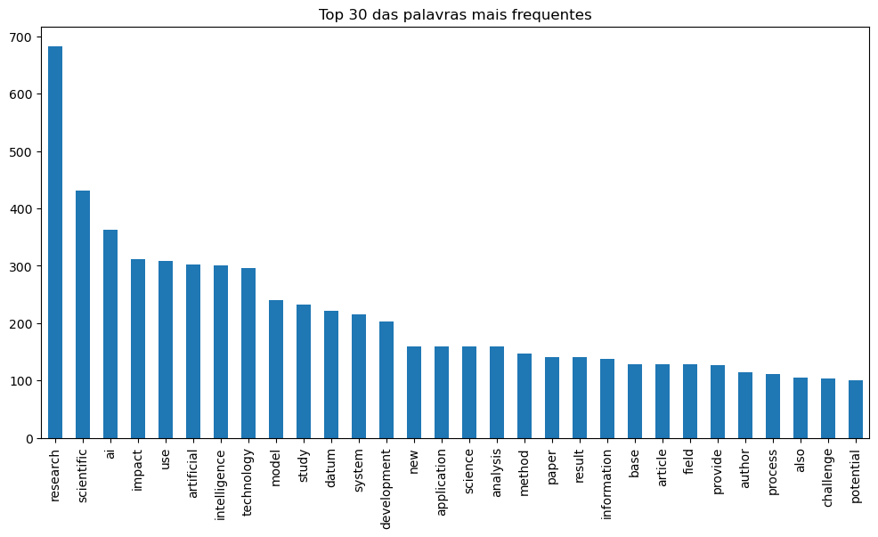

```python
# Gráfico de frequência de palavras

# Criar uma lista com todas as palavras finais
all_words = [word for lista in df['Final_words'] for word in lista]

# Contar a frequência de cada palavra
word_freq = pd.Series(all_words).value_counts()

# Mostrar o gráfico
plt.figure(figsize=(12,6))
word_freq.sort_values(ascending=False).head(30).plot(kind='bar')
plt.title('Top 30 das palavras mais frequentes')
plt.show()
```

### Remoção de palavras adicionais

Remoção adicional de palavras consideradas pouco significativas no contexto desta análise de texto, nomeadamente as palavras da expressão de pesquisa e outras pouco relevantes/significativas que se destacaram no gráfico das 30 palavras mais frequentes. A remoção das palavras da expressão de pesquisa foi realizada com o intuito de realçar os tópicos dentro do grande tema/tópico pesquisado.

```python
# Remover palavras adicionais
palavras_adicionais = ['impact', 'artificial',
                    'intelligence', 'scientific', 'research', 'ai', 'use', 'provide', 'author',
                    'also']

# Aplicar palavras_adicionais à lista de stopwords e aplicar
stop_words = set(stopwords.words('english'))
stop_words.update(palavras_adicionais)

# Remover stopwords da lista de palavras
df['Final_words1'] = df['Final_words'].apply(lambda x: [word for word in x if word not in stop_words])
df[['Final_words', 'Final_words1']].head(5)
```

|  | Final_words | Final_words1 |
| --- | --- | --- |
| 0 | [sustainable, agriculture, key, find, balance,... | [sustainable, agriculture, key, find, balance,... |
| 1 | [decision-making, pre-processing, entropy-base... | [decision-making, pre-processing, entropy-base... |
| 2 | [covid--related, covid-, covid-, top-cited, pu... | [covid--related, covid-, covid-, top-cited, pu... |
| 3 | [multi-step, structure-performance, single-ste... | [multi-step, structure-performance, single-ste... |
| 4 | [tech-savvy, ai-congruent, rapid, advancement,... | [tech-savvy, ai-congruent, rapid, advancement,... |

### Frequência de palavras após remoção de palavras adicionais

Apresentação da contagem de frequência de cada palavra.

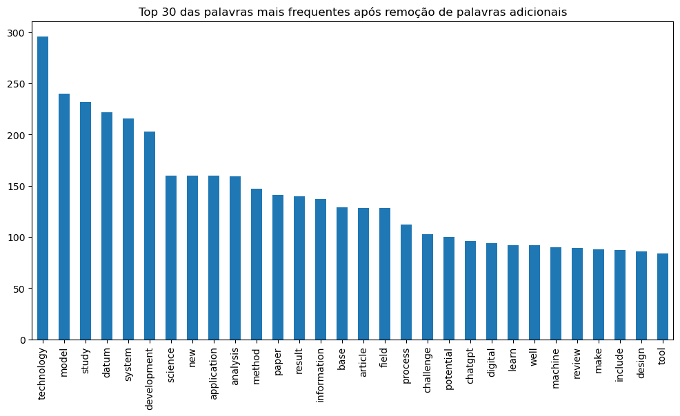

```python
# Gráfico de frequência de palavras após remoção de palavras adicionais

# Criar uma lista com todas as palavras exceto as palavras adicionais
all_words = [word for lista in df['Final_words1'] for word in lista]

# Contar a frequência de cada palavra
word_freq = pd.Series(all_words).value_counts()

# Mostrar o gráfico
plt.figure(figsize=(12,6))
word_freq.sort_values(ascending=False).head(30).plot(kind='bar')
plt.title('Top 30 das palavras mais frequentes após remoção de palavras adicionais')
plt.show()
```

## 3. Vetorização

Aplicação de técnicas de transformação de texto em bruto num formato passível de ser compreendido por algoritmos de aprendizagem automática:

- Vetorização de dados: Bag-Of-Words
- Vetorização de dados: N-Grams (2-grams)
- Term Frequency-Inverse Document Frequency (TF-IDF)

### Bag-Of-Words

Conversão de cada documento num vetor e representação da frequência de cada palavra única, não tendo em conta a ordem das palavras e concentrando-se apenas na sua ocorrência.

```python
# Iniciar CountVectorizer
vectorizer = CountVectorizer()

# Ajustar e transformar a coluna 'Final_Words1'
X = vectorizer.fit_transform(df['Final_words1'].apply(lambda x: ' '.join(x)))

# Converter a matriz BoW num DataFrame
bow_df = pd.DataFrame(X.toarray(), columns=vectorizer.get_feature_names_out())

# Mostrar o DataFrame resultante
print(bow_df)
```

```
     aa  abdominal  abedalkarim  ability  able  above  abroad  abs  absence  \
0     0          0            0        0     0      0       0    0        0
1     0          0            0        0     0      0       0    0        0
2     0          0            0        0     0      0       0    0        0
3     0          0            0        0     0      0       0    0        0
4     0          0            0        0     0      0       0    0        0
..   ..        ...          ...      ...   ...    ...     ...  ...      ...
238   0          0            0        0     0      0       0    0        0
239   0          0            0        0     0      0       0    0        0
240   0          0            0        0     0      0       0    0        0
241   0          0            0        0     0      0       0    0        0
242   0          0            0        0     0      0       0    0        0

     absolute  ...  zeph  zerogpt  zhanna  zhi  zinc  ziwei  zone  zoom  zou  \
0           0  ...     0        0       0    0     0      0     0     0    0
```

[output cut: 25 more lines]

*Gráfico das palavras mais comuns*

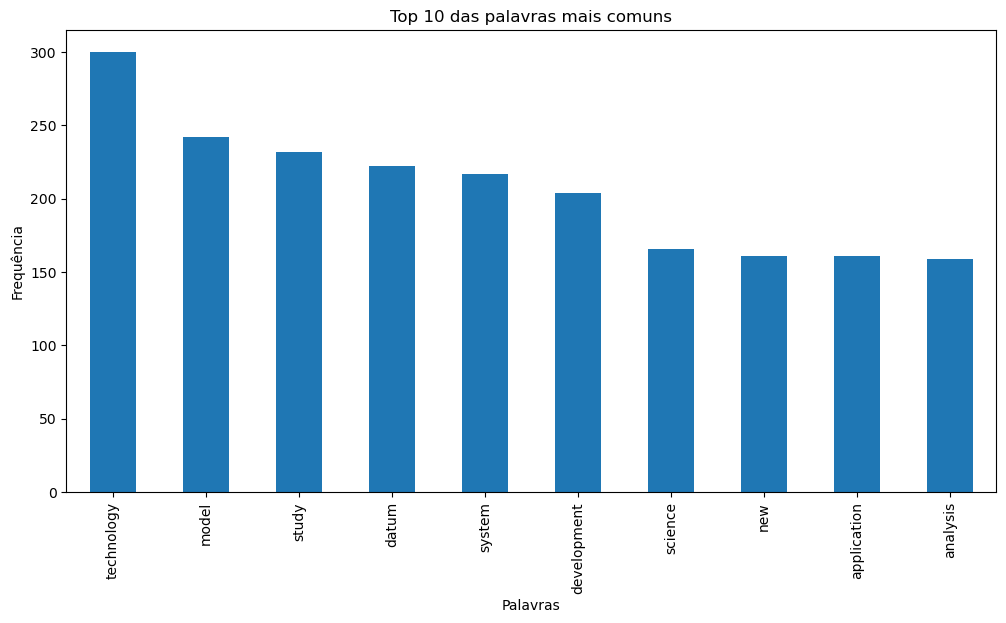

```python
# Somar as contagens de cada palavra
sum_words = bow_df.sum(axis=0)

# Ordenar e selecionar as 10 prinipais palavras
sorted_words = sum_words.sort_values(ascending=False)[:10]

# Mostrar gráfico
plt.figure(figsize=(12, 6))
sorted_words.plot(kind='bar')
plt.title('Top 10 das palavras mais comuns')
plt.xlabel('Palavras')
plt.ylabel('Frequência')
plt.show()
```

### N-Grams (2-grams/bigrams)

Vetorização de texto com base em bigramas. Ao contrário da técnica Bag-Of-Words, os N-gramas não consideram cada palavra de forma independente e sim uma sequência de palavras, neste caso, pares de palavras consecutivas. Desta forma, obtém-se mais algum contexto.

```python
# Iniciar CountVectorizer com o parâmetro bigrama
vectorizer = CountVectorizer(ngram_range=(2, 2))

# Ajustar e transformar a coluna 'Final_Words1'
X = vectorizer.fit_transform(df['Final_words1'].apply(lambda x: ' '.join(x)))

# Converter a matriz BoW num DataFrame
ngram_df = pd.DataFrame(X.toarray(), columns=vectorizer.get_feature_names_out())

# Mostrar o DataFrame resultante
print(ngram_df)
```

```
     aa gorbunov  aa ustinin  abdominal image  abedalkarim ayyoub  \
0              0           0                0                   0
1              0           0                0                   0
2              0           0                0                   0
3              0           0                0                   0
4              0           0                0                   0
..           ...         ...              ...                 ...
238            0           0                0                   0
239            0           0                0                   0
240            0           0                0                   0
241            0           0                0                   0
242            0           0                0                   0

     ability ability  ability analyze  ability cgh  ability collect  \
0                  0                0            0                0
```

[output cut: 51 more lines]

*Gráfico dos bigramas mais comuns*

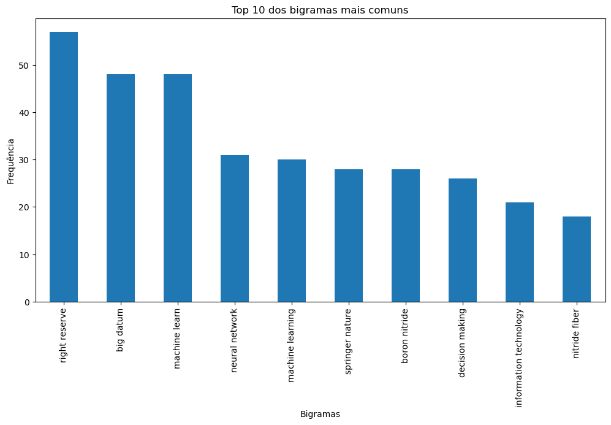

```python
# Somar as contagens de cada bigrama
sum_words = ngram_df.sum(axis=0)

# Ordenar e selecionar os 10 principais bigramas
sorted_words = sum_words.sort_values(ascending=False)[:10]

# Mostrar gráfico
plt.figure(figsize=(12, 6))
sorted_words.plot(kind='bar')
plt.title('Top 10 dos bigramas mais comuns')
plt.xlabel('Bigramas')
plt.ylabel('Frequência')
plt.show()
```

### Term Frequency-Inverse Document Frequency (TF-IDF)

Aplicação da técnica Term Frequency-Inverse Document Frequency (TF-IDF) que tem em conta não só a frequência de uma palavra num determinado documento (Term Frequency), mas também o grau de exclusividade da palavra em todos os documentos (Inverse Document Frequency), atribuindo dessa forma um peso maior às palavras que são mais informativas.

```python
# Iniciar TfidfVectorizer
tfidf_vectorizer = TfidfVectorizer()

# Adaptar e transformar os resumos limpos
tfidf_matrix = tfidf_vectorizer.fit_transform(df['Final_words1'].apply(lambda x: ' '.join(x)))

# Converter para matriz e depois para DataFrame para uma melhor visualização
tfidf_df = pd.DataFrame(tfidf_matrix.toarray(), columns=tfidf_vectorizer.get_feature_names_out())

print(tfidf_df)
```

```
      aa  abdominal  abedalkarim  ability  able  above  abroad  abs  absence  \
0    0.0        0.0          0.0      0.0   0.0    0.0     0.0  0.0      0.0
1    0.0        0.0          0.0      0.0   0.0    0.0     0.0  0.0      0.0
2    0.0        0.0          0.0      0.0   0.0    0.0     0.0  0.0      0.0
3    0.0        0.0          0.0      0.0   0.0    0.0     0.0  0.0      0.0
4    0.0        0.0          0.0      0.0   0.0    0.0     0.0  0.0      0.0
..   ...        ...          ...      ...   ...    ...     ...  ...      ...
238  0.0        0.0          0.0      0.0   0.0    0.0     0.0  0.0      0.0
239  0.0        0.0          0.0      0.0   0.0    0.0     0.0  0.0      0.0
240  0.0        0.0          0.0      0.0   0.0    0.0     0.0  0.0      0.0
241  0.0        0.0          0.0      0.0   0.0    0.0     0.0  0.0      0.0
242  0.0        0.0          0.0      0.0   0.0    0.0     0.0  0.0      0.0

     absolute  ...  zeph  zerogpt  zhanna  zhi  zinc  ziwei  zone  zoom  zou  \
0         0.0  ...   0.0      0.0     0.0  0.0   0.0    0.0   0.0   0.0  0.0
```

[output cut: 25 more lines]

*Gráfico dos TF-IDF mais comuns*

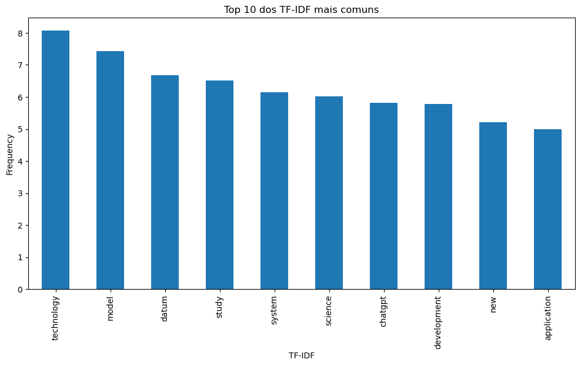

```python
# Somar as contagens de cada TF-IDF
sum_tfidf = tfidf_df.sum(axis=0)

# Ordenar e selecionar os 10 principais TF-IDF
sorted_tfidf = sum_tfidf.sort_values(ascending=False)[:10]

# Mostrar gráfico
plt.figure(figsize=(12, 6))
sorted_tfidf.plot(kind='bar')
plt.title('Top 10 dos TF-IDF mais comuns')
plt.xlabel('TF-IDF')
plt.ylabel('Frequency')
plt.show()
```

*Nuvem de palavras do TF-IDF*

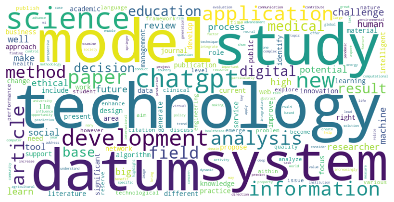

```python
# Gerar nuvem de palavras
wordcloud = WordCloud(width=800, height=400, background_color='white').generate_from_frequencies(sum_tfidf)

# Mostrar nuvem de palavras
plt.figure(figsize=(10, 5))
plt.imshow(wordcloud, interpolation='bilinear')
plt.axis('off')
plt.show()
```

## 4. Modelação

### Dimensões latentes - Tópicos

Identificação de dimensões latentes nos textos através do modelo Latent Dirichlet Allocation (LDA).

```python
from gensim.corpora import Dictionary

# Criar dicionário
dictionary = Dictionary(df['Final_words1'])

# Criar corpus
corpus = [dictionary.doc2bow(text) for text in df['Final_words1']]

# Mostrar o dicionário e o corpus
print(dictionary)
print(corpus[:1])  # Mostrar o corpus do primeiro documento
```

```
Dictionary<5165 unique tokens: ['accurate', 'achieve', 'action', 'additional', 'agriculture']...>
[[(0, 1), (1, 1), (2, 1), (3, 1), (4, 1), (5, 1), (6, 1), (7, 1), (8, 2), (9, 1), (10, 1), (11, 1), (12, 1), (13, 1), (14, 1), (15, 1), (16, 1), (17, 1), (18, 1), (19, 1), (20, 1), (21, 2), (22, 1), (23, 2), (24, 1), (25, 1), (26, 1), (27, 1), (28, 1), (29, 1), (30, 1), (31, 1), (32, 2), (33, 1), (3…
```

```python
# Executar o modelo LDA - utilizar o dicionário e o corpus para executar o modelo LDA
lda_model = LdaModel(corpus, num_topics=6, id2word=dictionary, passes=15, random_state=0)

# Mostrar os tópicos
topics = lda_model.print_topics(num_words=4)
for topic in topics:
    print(f'Topic {topic[0]}: Words: {topic[1]}')
```

```
Topic 0: Words: 0.009*"technology" + 0.007*"science" + 0.006*"information" + 0.006*"paper"
Topic 1: Words: 0.015*"datum" + 0.010*"model" + 0.006*"paper" + 0.006*"big"
Topic 2: Words: 0.009*"study" + 0.009*"chatgpt" + 0.008*"technology" + 0.007*"ethical"
Topic 3: Words: 0.013*"technology" + 0.011*"system" + 0.009*"development" + 0.009*"application"
Topic 4: Words: 0.006*"technology" + 0.006*"model" + 0.005*"water" + 0.004*"datum"
Topic 5: Words: 0.007*"technology" + 0.007*"study" + 0.007*"development" + 0.006*"analysis"
```

*Visualização interactiva do modelo de tópicos*

```python
pyLDAvis.enable_notebook()
vis = gensimvis.prepare(lda_model, corpus, dictionary)
pyLDAvis.display(vis)

#Exportar para json e html - não descomentar
#pyLDAvis.save_html(vis, 'lda_vis.html')
```

[interactive chart not shown]

```python
def get_document_topics(doc_bow):
    doc_topics = lda_model.get_document_topics(doc_bow)
    return [topic_prob for topic_id, topic_prob in doc_topics]

df['document_topics'] = df['Final_words1'].apply(lambda x: dictionary.doc2bow(x)).apply(get_document_topics)

df['document_topics'].head(10)
```

```
0                            [0.9926812]
1                [0.5709982, 0.42361555]
2                           [0.99229246]
3                 [0.03961537, 0.954735]
4               [0.9373035, 0.055394147]
5                           [0.99528694]
6    [0.13915549, 0.5302126, 0.32320422]
7                           [0.99317205]
8                            [0.9899964]
9                [0.52333254, 0.4680381]
Name: document_topics, dtype: object
```

*Nuvem de palavras de cada tópico*

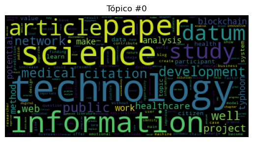

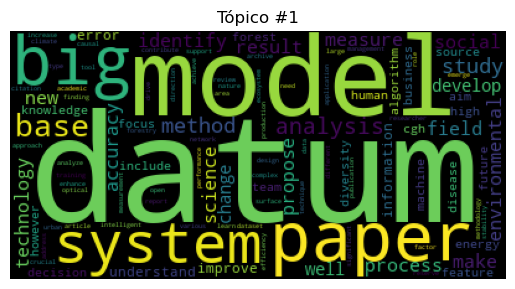

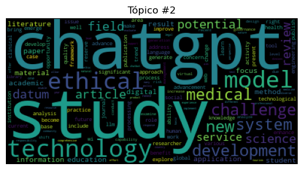

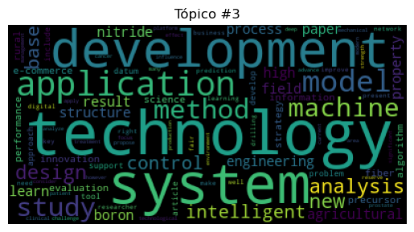

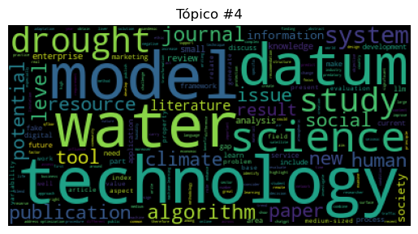

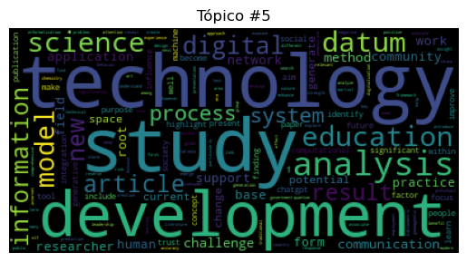

```python
for t in range(lda_model.num_topics):
    plt.figure()
    plt.imshow(WordCloud().fit_words(dict(lda_model.show_topic(t, 200))))
    plt.axis("off")
    plt.title("Tópico #" + str(t))
    plt.show()
```

### Clustering - a partir do texto limpo

#### Definição do número de clusters (K)

Um método comum para determinar o número ótimo de clusters é o método do cotovelo. Executa-se o algoritmo K-means para uma gama de valores K e traça-se a soma das distâncias quadradas de cada ponto ao centro que lhe foi atribuído.

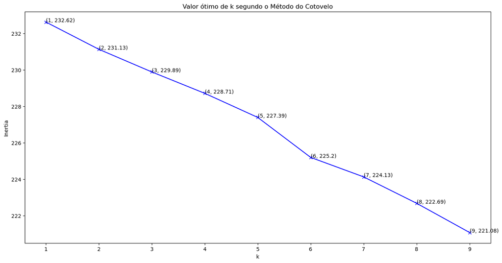

```python
# Método do Cotovelo
inertia = []
K = range(1, 10)  # Verificar até 10 clusters

for k in K:
    kmeans = KMeans(n_clusters=k, random_state=0)
    kmeans.fit(tfidf_df)
    inertia.append(kmeans.inertia_)

plt.figure(figsize=(16, 8))
plt.plot(K, inertia, 'bx-')
plt.xlabel('k')
plt.ylabel('Inertia')
plt.title('Valor ótimo de k segundo o Método do Cotovelo')

# Mostrar valores de inércia em cada ponto
for i in range(len(K)):
    plt.text(K[i], inertia[i], (K[i], round(inertia[i], 2)))
plt.show()
```

#### Execução de clustering K-means

```python
k_optimal=6
```

```python
kmeans = KMeans(n_clusters=k_optimal, random_state=0)
clusters = kmeans.fit_predict(tfidf_df)
df['Cluster'] = clusters
```

#### Análise dos clusters

```python
for i in range(6):
    print(f"Cluster {i}:")
    print(df[df['Cluster'] == i]['Final_words1'])
```

```
Cluster 0:
1      [decision-making, pre-processing, entropy-base...
15     [resource-intensive, pervasive, deployment, de...
31     [data-driven, data-driven, big, datum, represe...
37     [computational, tool, particularly, become, ub...
42     [context-dependent, study, investigate, relati...
45     [multi-dimensional, cross-disciplinary, medica...
68     [mean-shift, high-precision, archives-, -, mea...
91     [large-scale, k-means, k-cluster, k-cluster, f...
96     [covid-, fifty-three, committee-international,...
100    [high-impact, non-commercial, non-commercial, ...
101    [development, society, widely, many, field, fa...
106    [gpt-, gpt-, peer-to-peer, human-computer, hig...
127    [chapter, consider, actualize, problem, applic...
129    [co-authorship, small-sized, team, play, incre...
```

[output cut: 186 more lines]

### Clustering - a partir dos tópicos

#### Distribuição de tópicos para cada documento

```python
# Obter a distribuição de tópicos para cada documento
doc_topic_dist = [lda_model.get_document_topics(bow) for bow in corpus]

# Iniciar uma matriz com zeros
doc_topic_matrix = np.zeros((len(doc_topic_dist), lda_model.num_topics))

# Preencher a matriz
for i, doc in enumerate(doc_topic_dist):
    for topic, prob in doc:
        doc_topic_matrix[i, topic] = prob

# Mostrar a matriz com tópicos como cabeçalhos
doc_topic_matrix = pd.DataFrame(doc_topic_matrix, columns=[f'Topic {i}' for i in range(lda_model.num_topics)])
print(doc_topic_matrix.head)

# Em cada tópico, encontrar os 3 documentos com a maior probabilidade
most_relevant_docs = {}
for i in range(lda_model.num_topics):
    most_relevant_docs[i] = np.argsort(doc_topic_matrix[f'Topic {i}'].values)[::-1][:3]

# Mostrar os documentos mais relevantes para cada tópico
results = []
for topic, docs in most_relevant_docs.items():
    print(f'Topic {topic}:')
    for doc in docs:
        print(df.iloc[doc]['Title'])
        results.append({'Topic': topic, 'Document Title':df.iloc[doc]['Title']})
    print('\n')

# Converter o dicionario most_relevant_docs
df_relevant_docs=pd.DataFrame(results)

# Exportar a matriz de tópicos para um ficheiro CSV - nao descomentar
#doc_topic_matrix.to_csv('document_topic_distribution.csv', index=False, sep=';', quotechar='"')
#df_relevant_docs.to_csv('most_relevant_docs.csv', index=False, sep=';', quotechar='"')
```

```
<bound method NDFrame.head of       Topic 0   Topic 1   Topic 2   Topic 3   Topic 4   Topic 5
0    0.000000  0.000000  0.000000  0.992682  0.000000  0.000000
1    0.571004  0.000000  0.000000  0.423610  0.000000  0.000000
2    0.000000  0.000000  0.992292  0.000000  0.000000  0.000000
3    0.000000  0.000000  0.000000  0.039102  0.000000  0.955248
4    0.000000  0.937219  0.055479  0.000000  0.000000  0.000000
..        ...       ...       ...       ...       ...       ...
238  0.000000  0.193596  0.000000  0.000000  0.797068  0.000000
239  0.000000  0.000000  0.798090  0.195450  0.000000  0.000000
240  0.000000  0.000000  0.000000  0.000000  0.995462  0.000000
241  0.985479  0.000000  0.000000  0.000000  0.000000  0.000000
242  0.231532  0.760899  0.000000  0.000000  0.000000  0.000000

[243 rows x 6 columns]>
Topic 0:
Blockchain 3.0 for sustainable healthcare
Pathological changes or technical artefacts? The problem of the heterogenous databases in COVID-19 CXR image analysis
Longform Multimodal Lay Summarization of Scientific Papers: Towards Automatically Generating Science Blogs from Research Articles


Topic 1:
Analysis of the current status of research on accuracy traceability based on computational holographic detection technology(inner cover paper); [计算全息检测技术的精度溯源研究现状分析（内封面文章）]
Big Data in mechanical research: Potentials, applications and challenges; [力学研究中"大数据"的启示, 应用与挑战]
On the Research of Climate-Smart Forestry; [关于“气候智慧林业”研究的思考]


Topic 2:
Grasping the new characteristics of new sci-tech revolution and its ethical issues for scientific and technological ethics governance; [科技伦理治理要准确把握新科技革命及其伦理问题的新特点]
ChatGPT and the Its Impact on the Development Trends of the Library Field; [ChatGPT 与图书馆的领域动向]
Impacts of groundwater and climate variability on terrestrial groundwater dependent ecosystems: a review of geospatial assessment approaches and challenges and possible future research directions


Topic 3:
2014 3rd International Conference on Intelligent System and Applied Material, GSAM 2014
Advances in Preparation of Boron Nitride Ceramic Fiber via Polymer-Derived Ceramics; [先驱体转化法制备氮化硼陶瓷纤维研究进展]
Problems of Regulation and Prospective Development of E-commerce Systems in the Post-coronavirus Era


Topic 4:
Impacts of climate variability and drought on surface water resources in sub-saharan africa using remote sensing: A review
Adaptation of small and medium-sized enterprises in the service sector to the conditions of Industry 4.0 and Society 4.0: evidence from the Czech Republic
AI alignment: Assessing the global impact of recommender systems


Topic 5:
Academic expression: Development trends of scientific articles driven by technology; [学术与表达: 技术驱动下的科技论文发展趋势]
Riparian restoration in sandy zones with alfalfa as pioneer plant in initial stage of soil and water bioengineering
SUBJECTNESS OF DIGITAL COMMUNICATION IN THE CONTEXT OF THE TECHNOLOGICAL EVOLUTION OF THE CONTEMPORARY SOCIETY: THREATS, CHALLENGES, AND RISKS1; [TEMATYKA KOMUNIKACJI CYFROWEJ W KONTEKŚCIE EWOLUCJI TECHNOLOGICZNEJ WSPÓŁCZESNEGO SPOŁECZEŃSTWA:]
```

#### Execução da clusterização na distribuição de tópicos

```python
# Efetuar a clusterização K-means (6 clusters)
kmeans = KMeans(n_clusters=6, random_state=0)
clusters = kmeans.fit_predict(doc_topic_matrix)

# Adicionar etiquetas de cluster ao DataFrame original
df['Topic_Cluster'] = clusters
```

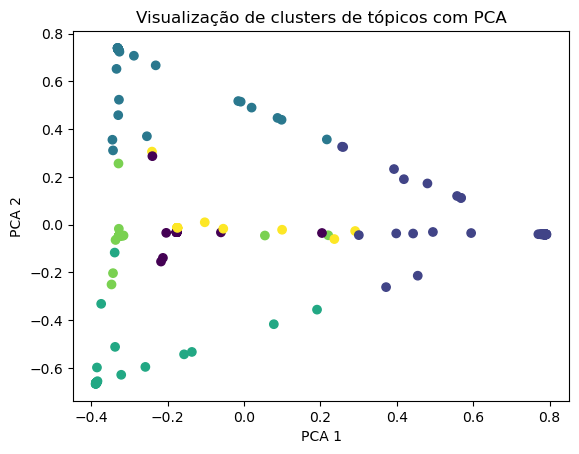

```python
from sklearn.decomposition import PCA
import matplotlib.pyplot as plt

# Executar PCA para redução da dimensionalidade
pca = PCA(n_components=2, random_state=0)
reduced_features = pca.fit_transform(doc_topic_matrix)

# Mostrar os cluster
plt.scatter(reduced_features[:, 0], reduced_features[:, 1], c=clusters)
plt.xlabel('PCA 1')
plt.ylabel('PCA 2')
plt.title('Visualização de clusters de tópicos com PCA')
plt.show()
```

```python
# Analisar clusters
for i in range(6):  # 6 clusters
    print(f"Cluster {i}:")
    print(df[df['Topic_Cluster'] == i]['Final_words1'])
```

```
Cluster 0:
8      [on-going, open-access, interview, teresa, esc...
16     [day-to-day, forward-looking, cutting-edge, hu...
24     [fast-growing, launch, chatgpt, lead, userbase...
30     [nature-inspired, non-linear, -plus, high-impa...
40     [recently, intelligent, transportation, system...
52     [risk-based, ethics, field, currently, work, t...
59     [long-standing, algorithm-based, well-being, r...
60     [covid-, open-access, early-career, early-care...
90     [ai-plagiarism, fast-paced, chatgpt, chatbot, ...
95     [human-like, gpt-, photo-realistic, publicatio...
96     [covid-, fifty-three, committee-international,...
113    [start-ups, decision-making, audio-visual, exp...
122    [semi-arid, sub-saharan, in-situ, sub-saharan,...
133    [in-time, medium-sized, cyber-physical, medium...
```

[output cut: 186 more lines]

```python
# Armazenar resultados em uma lista
results = []

# Analisar clusters e armazenar títulos dos documentos
for i in range(6):  # 6 clusters
    cluster_docs = df[df['Topic_Cluster'] == i]['Title']
    for title in cluster_docs:
        results.append({'Cluster': f"{i}", 'Title': f"{title}"})

# Converter a lista de resultados para DataFrame
result_df = pd.DataFrame(results)

# Exportar para um arquivo CSV - não descomentar
#result_df.to_csv('clustered_documents.csv', index=False, sep=';', quotechar='"')

# Visualizar o output
result_df
```

|  | Cluster | Title |
| --- | --- | --- |
| 0 | 0 | I Like Thinking About the Best Way to Word Som... |
| 1 | 0 | Harnessing the power of artificial intelligenc... |
| 2 | 0 | Has the AI Revolution Started Yet? |
| 3 | 0 | Hybridized artificial intelligence models with... |
| 4 | 0 | A Survey on Traffic Sign Classification using ... |
| ... | ... | ... |
| 238 | 5 | The Top 100 Articles in the Medical Informatic... |
| 239 | 5 | Limit cycle stabilizing receding-horizon contr... |
| 240 | 5 | Analysis of web mining technology and their im... |
| 241 | 5 | Understanding artefacts related to human aspec... |
| 242 | 5 | Towards use of grids in environmental research... |

243 rows × 2 columns

*Mapa de calor da distribuição dos tópicos*

Visualização da distribuição dos tópicos nos diferentes clusters de documentos.

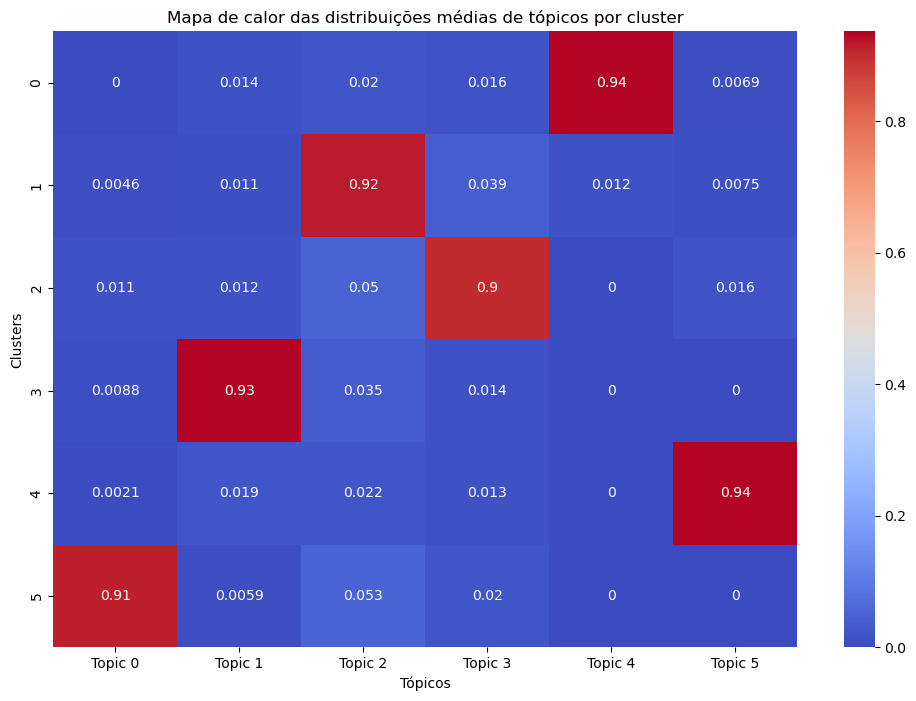

```python
import seaborn as sns
import pandas as pd

# Criar um DataFrame a partir da matriz de distribuição de tópicos e das etiquetas de clusters
topic_df = pd.DataFrame(doc_topic_matrix)
topic_df['Cluster'] = clusters

# Calcular a distribuição média de tópicos para cada cluster
cluster_means = topic_df.groupby('Cluster').mean()

# Criar o mapa de calor
plt.figure(figsize=(12, 8))
sns.heatmap(cluster_means, annot=True, cmap='coolwarm')
plt.title('Mapa de calor das distribuições médias de tópicos por cluster')
plt.xlabel('Tópicos')
plt.ylabel('Clusters')
plt.show()
```